# Does the reproduction state,gender and age of an animal affect whether or not the animal is adopted?

Ru

10/8/2018

### Introduction

The main purpose of this analysis is to explore how to deal with datasets that violate the normal statistical assumptions using Generalized Linear Models.

Briefly, in generalized linear models, the response variable follows an exponential family distribution with mean $\mu$ which is a function of a usually non-linear beta. This paper will specifically be going through logistic regression - a statistical technique that is used to explain the relationship between one response binary variable $y$ and one or more predictor variables.

# The dataset

The dataset belongs to [Austin Animal Center](http://www.austintexas.gov/department/aac) and contained 92698 animals including cats, dogs, birds, and livestock. This dataset had 12 variables including the Animal ID, name of the animal, date-time, and month year (which I later found out had the same information), date of birth, outcome type, outcome subtype, animal type, sex upon outcome, age upon outcome, breed and color of the animal.

## Predictors

### Age

I was interested in finding out the effect of sex, age and gender on whether or not a dog was adopted. Initially, I thought I could easily use the `Sex.upon.Outcome`, and `Age.upon.Outcome` variables. However, as I learnt more about my data, the dataset proved I would not want to use these variables as they are.

Reasons why I would not use the Age.upon.Outcome variable:

• It’s a categorical variable. While this may not be an issue if we were dealing with another statistical model, it would definitely not be in our best interest to use the Age.upon.Outcome variable. Using the group_by function in dplyr, I found out there were 49 different ages of the animal.

| Age.upon.Outcome | n |
| --- | --- |
| -1 years | 1 |
| 0 years | 118 |
| 1 day | 184 |
| 1 month | 4060 |
| 1 week | 500 |
| 1 weeks | 618 |

Besides this weird dilemma, it just makes conceptual sense to use age as a number… and therefore a continuous variable as it conventionally is. Let’s clean age up a little bit.

### Clean up of Age:

The dataset had a DateTime variable that showed the day an outcome happened to an animal, and the Date.of.Birth of the animal so I subtracted the `DateTime` from the `Date.Of.Birth` and created a new variable `Age_in_years`:

```r
#dates
#change factors to date
Austin_Animals$DateTime =as.Date(Austin_Animals$DateTime, format = "%m/%d/%Y")
Austin_Animals$Date.of.Birth = as.Date(Austin_Animals$Date.of.Birth, format = "%m/%d/%Y")

#get the difference between the two dates
Austin_Animals$Age_in_years = as.numeric(difftime(as.Date(Austin_Animals$DateTime),
                    as.Date(Austin_Animals$Date.of.Birth),unit="weeks"))/52.25
```

## Sex

There were four levels of sex.upon. Outcome: 1. Neutered Male 2. Intact Male 3. Spayed Female 4. Intact Female

I added a new variable, `reproduction_state`, which tells us whether the animal was fixed(i.e intact) or not fixed(in this case, either neutered or spayed). I also added the variable `gender` which tells us whether the animal is female or male.

Splitting this variable into two different variables enables us to have a better understanding on whether the reproduction state of an animal affects whether or not it is adopted depending on its gender. Null or unknown values of the animal’s sex were removed.

```r
Austin_Animals = Austin_Animals%>%
  mutate(reproduction_state = ifelse(str_detect(Austin_Animals$Sex.upon.Outcome,"Intact"),"Fixed","Not Fixed"),gender = ifelse(str_detect(Austin_Animals$Sex.upon.Outcome,"Female"),"Female","Male"))%>%
  filter(Sex.upon.Outcome != "Unknown")%>%
  filter(Sex.upon.Outcome != "NULL")
```

## The response variable:Outcome Type

### Data Cleaning:

The purpose of this analysis is to learn more about binary logistic regression. However, our response variable has 9 variables:

| Outcome.Type | num_animals |
| --- | --- |
| Adoption | 39973 |
| Transfer | 24605 |
| Return to Owner | 16838 |
| Euthanasia | 3031 |
| Died | 581 |
| Rto-Adopt | 308 |
| Missing | 48 |
| Disposal | 38 |
|  | 1 |
| Relocate | 1 |

*Now what?*

I changed `Adoption` and `Rto-Adopt` level to be `Adopted` and the rest as `Not Adopted` so as to remain with only two levels for my data.

One might wonder why I did not filter out the rest and this is because removing all those levels would eventually leave us with just a few options and bias our estimates for the regression coeefients. I do understand that some bias will be created as one can argue that keeping the “transferred” level" will also add some bias in the model as we do not know whether the transferred animals were later adopted or not, but as of the time the dataset was created, the animal had not been adopted so the bias caused by this would not be as high as the bias caused by totally removing the levels of our factor.

## Data Models

### Checking correlation between variables

I used Cramer’s values to check for possible multi-colinearity between my predictor variable before building the model:

|  | adoption | Age_in_years | reproduction_state | gender |
| --- | --- | --- | --- | --- |
| adoption | 1.0000000 | 0.4517300 | 0.5472867 | 0.0151724 |
| Age_in_years | 0.4517300 | 1.0000000 | 0.4993887 | 0.3043011 |
| reproduction_state | 0.5472867 | 0.4993887 | 1.0000000 | 0.0264859 |
| gender | 0.0151724 | 0.3043011 | 0.0264859 | 1.0000000 |

*What do these Cramer’s values mean?*

Crammer’s Value show the strength of the relationships between our variables. Values close to 0 determine little relationship between variables, values close to 1 determine strong correlation. In this case, we see that the predictors with the strongest relationship with the adoption outcome are the reproduction_state and Age_in_years. Crammers V 0.55 and 0.45 respectively. I will therefore use these predictors to build my model.

# Visualizing logistic regression

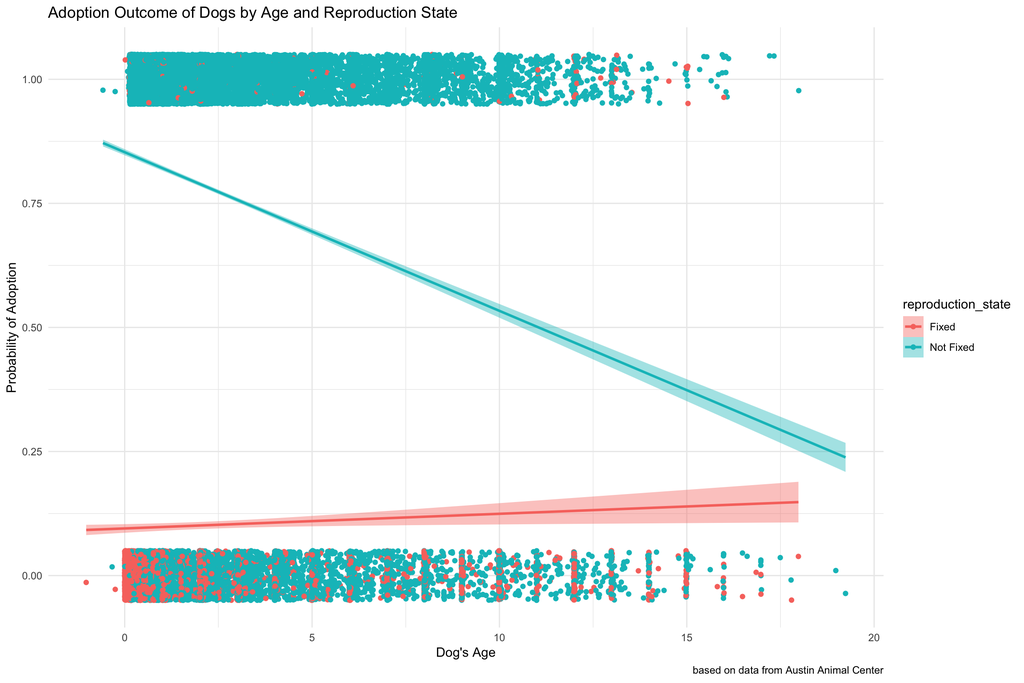

We can also see that there are more fixed animals at younger ages.

# Building a model with Logistic Regression

Logistic regression is a non-linear regression model that is used to measure categorical response variables. Binary logistic regression is used when there are two possible response outcomes (in this case, `Adopted`, or `Not Adopted`).

Logistic regression can be used to:

*Model* the probability of an event occuring depending on the values of the independent variables *Estimate* the probability that an event occurs for a randomly selected observation versus the probability that the event does not occur. *Predict* the effect of a series of variables on a binary response variable. In this case, it would be working just like simple and multiple linear regression. *Classify* observations by estimating the probability that an observation is in a particular category(such as adopted or not adopted in this case)

## Why logistic regression:

Reasons why we use binary logistic regression rather than linear regression: 1. Non-normal error terms 2. Non–constant error variance 3. Constraints on response functions- This occurs because when measuring the binary response, we only have two outcomes. 1- something occurs or 0- nothing occurs. Therefore, when measuring the response, lets picture it as measuring the likelihood that something occurs or does not occur. This is almost the same as measuring the probability that something happens and in this situation, we cannot have a more than 1 chance that something happens or a less than 0 chance. Characteristics of the logistic regression function: 1. Is bounded between 0 and 1 2. Has a characteristic sigmoidal (S) shape 3. Approaches 0 and 1 asymptotically.

I separated my data into training and test data by getting a 70% sample of it and making it the training data and using 30% to make it the test data.

```r
train = clean_animals%>%
  sample_frac(0.70)
test = anti_join(clean_animals, train, by = 'Animal.ID')
```

Logistic regression predicts the true proportion of success, $\pi$ at any value of the explanatory variable $y = # of 1's/# of trials$ $\pi = proportion of successes (1's)$

```r
logtrain = glm(is_adopted~reproduction_state*Age_in_years, data= train, family=binomial)
summary(logtrain)
```

```
##
## Call:
## glm(formula = is_adopted ~ reproduction_state * Age_in_years,
##     family = binomial, data = train)
##
## Deviance Residuals:
##     Min       1Q   Median       3Q      Max
## -1.9380  -0.4561   0.6106   0.6804   2.1680
##
## Coefficients:
##                                          Estimate Std. Error z value
## (Intercept)                              -2.25064    0.05847  -38.49
## reproduction_stateNot Fixed               3.91024    0.06293   62.14
## Age_in_years                              0.03892    0.01514    2.57
## reproduction_stateNot Fixed:Age_in_years -0.19492    0.01614  -12.08
##                                          Pr(>|z|)
## (Intercept)                                <2e-16 ***
## reproduction_stateNot Fixed                <2e-16 ***
## Age_in_years                               0.0102 *
## reproduction_stateNot Fixed:Age_in_years   <2e-16 ***
## ---
## Signif. codes:  0 '***' 0.001 '**' 0.01 '*' 0.05 '.' 0.1 ' ' 1
##
## (Dispersion parameter for binomial family taken to be 1)
##
##     Null deviance: 33742  on 26138  degrees of freedom
## Residual deviance: 25124  on 26135  degrees of freedom
## AIC: 25132
##
## Number of Fisher Scoring iterations: 4
```

After building our model,we need to assess how accurately the model predicts whether or not an animal is adopted.

## Assessing the model

```r
glm_probs = data.frame(probs = predict(logtrain,
                                       newdata = test,
                                       type="response"))
glm_pred = glm_probs %>%
  mutate(pred = ifelse(probs>.80, "Adopted", "Not"))

glm_pred = cbind(test, glm_pred)

glm_pred %>%
  count(pred, is_adopted) %>%
  spread(is_adopted, n, fill = 0)
```

```
## # A tibble: 2 x 3
##   pred      `0`   `1`
##   <chr>   <dbl> <dbl>
## 1 Adopted   669  3557
## 2 Not      2965  2348
```

```r
glm_pred %>%
  summarize(score = mean(pred == is_adopted),
            recip = mean(pred != is_adopted))
```

```
##   score recip
## 1     0     1
```

References https://www.youtube.com/watch?v=zAULhNrnuL4 http://ddar.datavis.ca/pages/extra/titanic-glm-ex.pdf